# 3. Limpieza de datos

# Introducción

Este documento es la continuación de las notas anteriores:

1. C:/Prog/tesis/1_Primeros_pasos.Rmd
2. C:/Prog/tesis/INEGI-2023_Conociendo-ENOE.Rmd
3. C:/Prog/tesis/2_Analisis_exploratorio_datos1.Rmd

El objetivo es responder de forma concisa algunas de las preguntas de investigación esbozadas en la nota física del 23-10-25 mediante la utilización de la ENOE perteneciente al trimestre II del 2025.

# 1. Importar

```r
library(tidyverse)
# paleta de colores p. 422
library(RColorBrewer)
# letter value plot p. 99 (inglés)
library(lvplot)

# # 1. vivienda
# viv <- read_csv(
#   "enoet22025/ENOE_VIVT225.csv",
#   col_types = cols(.default = col_character())
# )

# # 2. hogar
# hog <- read_csv(
#   "enoet22025/ENOE_HOGT225.csv",
#   col_types = cols(.default = col_character())
# )

# 3. sociodemográfica
sdem <- read_csv(
  "enoet22025/ENOE_SDEMT225.csv",
  col_types = cols(.default = col_character())
)

# 4. ocupación y empleo I
coe1 <- read_csv(
  "enoet22025/ENOE_COE1T225.csv",
  col_types = cols(.default = col_character())
)

# 5. ocupación y empleo II
coe2 <- read_csv(
  "enoet22025/ENOE_COE2T225.csv",
  col_types = cols(.default = col_character())
)
```

# 2. Segmentar

```r
sdem<- sdem %>% mutate(
  # edad
  eda = as.integer(eda),
  # grupos de edad
  eda12c = as.integer(eda12c),
  # ponderador trimestral
  fac_tri = as.double(fac_tri),
  # ingreso mensual
  ingocup = as.double(ingocup),
  # promedio de ingreso por hora
  ing_x_hrs = as.double(ing_x_hrs)
)
```

## 2.1 Renombrar niveles

### Entidades federativas

Se valida los niveles de la variable `ent`

```r
unique(sdem$ent)
```

```
 [1] "9"  "14" "11" "5"  "24" "28" "30" "16" "27" "8"  "2"  "10" "18" "20" "32" "6"  "22" "29" "3"  "4"  "13" "25" "7"  "31"
[25] "12" "15" "19" "21" "17" "23" "26" "1"
```

Se renombran los niveles

```r
sdem %>%
  mutate(
    ent = factor(ent),
    ent = fct_recode(
      ent,
      "Aguascalientes" = "1",
      "Baja California" = "2",
      "Baja California Sur" = "3",
      "Campeche" = "4",
      "Coahuila de Zaragoza" = "5",
      "Colima" = "6",
      "Chiapas" = "7",
      "Chihuahua" = "8",
      "Ciudad de México" = "9",
      "Durango" = "10",
      "Guanajuato" = "11",
      "Guerrero" = "12",
      "Hidalgo" = "13",
      "Jalisco" = "14",
      "México" = "15",
      "Michoacán de Ocampo" = "16",
      "Morelos" = "17",
      "Nayarit" = "18",
      "Nuevo León" = "19",
      "Oaxaca" = "20",
      "Puebla" = "21",
      "Querétaro" = "22",
      "Quintana Roo" = "23",
      "San Luis Potosí" = "24",
      "Sinaloa" = "25",
      "Sonora" = "26",
      "Tabasco" = "27",
      "Tamaulipas" = "28",
      "Tlaxcala" = "29",
      "Veracruz de Ignacio de la Llave" = "30",
      "Yucatán" = "31",
      "Zacatecas" = "32"
    )
  ) %>%
  group_by(ent) %>%
  summarise(
    n = n(),
    pob_tot = sum(fac_tri)
  ) %>%
  arrange(desc(pob_tot))
```

| ent | n | pob_tot |
| --- | --- | --- |
| México | 17839 | 17764322 |
| Ciudad de México | 9671 | 9365788 |
| Jalisco | 13728 | 8752003 |
| Veracruz de Ignacio de la Llave | 18154 | 8126081 |
| Puebla | 14727 | 6592099 |
| Guanajuato | 16163 | 6313694 |
| Nuevo León | 13152 | 6161091 |
| Chiapas | 20832 | 5923036 |
| Michoacán de Ocampo | 11765 | 4955164 |
| Oaxaca | 14167 | 4241180 |

[output cut: 22 more lines]

Se asignan los nuevos niveles

```r
sdem <- sdem %>%
  mutate(
    ent = factor(ent),
    ent = fct_recode(
      ent,
      "Aguascalientes" = "1",
      "Baja California" = "2",
      "Baja California Sur" = "3",
      "Campeche" = "4",
      "Coahuila de Zaragoza" = "5",
      "Colima" = "6",
      "Chiapas" = "7",
      "Chihuahua" = "8",
      "Ciudad de México" = "9",
      "Durango" = "10",
      "Guanajuato" = "11",
      "Guerrero" = "12",
      "Hidalgo" = "13",
      "Jalisco" = "14",
      "México" = "15",
      "Michoacán de Ocampo" = "16",
      "Morelos" = "17",
      "Nayarit" = "18",
      "Nuevo León" = "19",
      "Oaxaca" = "20",
      "Puebla" = "21",
      "Querétaro" = "22",
      "Quintana Roo" = "23",
      "San Luis Potosí" = "24",
      "Sinaloa" = "25",
      "Sonora" = "26",
      "Tabasco" = "27",
      "Tamaulipas" = "28",
      "Tlaxcala" = "29",
      "Veracruz de Ignacio de la Llave" = "30",
      "Yucatán" = "31",
      "Zacatecas" = "32"
    )
  )
```

### Sexo

```r
sdem %>%
  transmute(
    sex = factor(sex),
    sex = fct_recode(
      sex,
      "Hombre" = "1",
      "Mujer" = "2"
    )
  ) %>%
  count(sex)
```

| sex | n |
| --- | --- |
| Hombre | 197821 |
| Mujer | 216059 |
| NA | 9864 |

Se encuestaron a más mujeres que hombres.

```r
sdem <- sdem %>%
  mutate(
    sex = factor(sex),
    sex = fct_recode(
      sex,
      "Hombre" = "1",
      "Mujer" = "2"
    )
  )
```

# 3. Grupos de edad

Construir los siguientes grupos de edad, a partir del campo precodificado `eda12c`:

1. 15 a 24: valor 1 y 2
2. 25 a 34: valor 3 y 4
3. 35 a 44: valor 5 y 6
4. 45 a 54: valor 7 y 8
5. 55 a 64: valor 9 y 10
6. 65 y más: valor 11

```r
sdem %>%
  transmute(
    edad_grupos = case_when(
      # de 15 a 24
      eda12c == 1 | eda12c == 2 ~ "1",
      # de 25 a 34
      eda12c == 3 | eda12c == 4 ~ "2",
      # de 35 a 44
      eda12c == 5 | eda12c == 6 ~ "3",
      # de 45 a 54
      eda12c == 7 | eda12c == 8 ~ "4",
      # de 55 a 64
      eda12c == 9 | eda12c == 10 ~ "5",
      # de 65 y más
      eda12c == 11 ~ "6",
      # no especificado (INEGI, 2024: 24)
      eda12c == 12 ~ "7",
      # de 0 a 14
      TRUE ~ "0"
    )
  ) %>%
  count(edad_grupos)
```

| edad_grupos | n |
| --- | --- |
| 0 | 99131 |
| 1 | 68906 |
| 2 | 59273 |
| 3 | 57496 |
| 4 | 53469 |
| 5 | 42072 |
| 6 | 43215 |
| 7 | 182 |

Se corrobora resultados con los valores del campo precodificado `eda12c`

```r
sdem %>%
  count(eda12c)
```

| eda12c | n |
| --- | --- |
| 0 | 99131 |
| 1 | 36179 |
| 2 | 32727 |
| 3 | 29197 |
| 4 | 30076 |
| 5 | 28852 |
| 6 | 28644 |
| 7 | 26870 |
| 8 | 26599 |
| 9 | 22248 |

[output cut: 3 more lines]

## Valor `0` en `eda12c`

¿Qué edades corresponden el valor `0` de `eda12c`?

```r
sdem %>%
  filter(eda12c == "0") %>%
  count(eda)
```

| eda | n |
| --- | --- |
| 0 | 3297 |
| 1 | 4120 |
| 2 | 4442 |
| 3 | 4832 |
| 4 | 5038 |
| 5 | 5537 |
| 6 | 5853 |
| 7 | 6305 |
| 8 | 6465 |
| 9 | 6650 |

[output cut: 84 more lines]

Se observa que el valor `0` de la variable `eda12` corresponde a las edades menores a 15 años, pero también tiene registro de personas con edad de 15 años o superior. Entonces, la variable `eda12c` no es de fiar; debo construir los grupos de edad a partir de la variable `eda`.

## 3.1 Asistencia escolar en edad de 20-24 años

Duda: ¿cuántos todavía asisten a la escuela en la edad de 20 a 24 años?

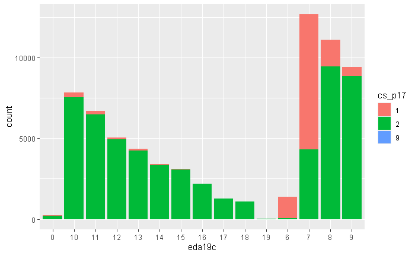

```r
sdem %>%
  filter(cs_p13_1 == 7) %>%
  ggplot(aes(eda19c)) +
  geom_bar(aes(fill = cs_p17))
```

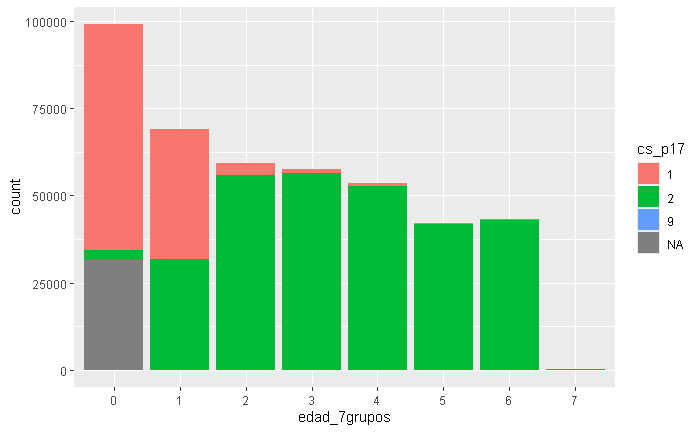

```r
sdem %>%
  mutate(
    edad_7grupos = case_when(
      # de 15 a 24
      eda12c == 1 | eda12c == 2 ~ "1",
      # de 25 a 34
      eda12c == 3 | eda12c == 4 ~ "2",
      # de 35 a 44
      eda12c == 5 | eda12c == 6 ~ "3",
      # de 45 a 54
      eda12c == 7 | eda12c == 8 ~ "4",
      # de 55 a 64
      eda12c == 9 | eda12c == 10 ~ "5",
      # de 65 y más
      eda12c == 11 ~ "6",
      # no especificado (INEGI, 2024: 24)
      eda12c == 12 ~ "7",
      # de 0 a 14
      TRUE ~ "0"
    )
  ) %>%
  ggplot(aes(edad_7grupos)) +
  geom_bar(aes(fill = cs_p17))
```

Con la variable creada, se observa que la mitad de encuestados pertenecientes al grupo de edad de 15 a 24 años reporta asistir actualmente a la escuela, mientras que alrededor del 95% del grupo de 25 a 34 años señala no acudir.

## 3.2 Definir grupos de edad

Por lo que, se deja la variable creada que identifica los grupos de edad, en línea con OECD (2019).

```r
sdem <- sdem %>% mutate(
  edad_7grupos = case_when(
      # de 15 a 24
      eda12c == 1 | eda12c == 2 ~ "1",
      # de 25 a 34
      eda12c == 3 | eda12c == 4 ~ "2",
      # de 35 a 44
      eda12c == 5 | eda12c == 6 ~ "3",
      # de 45 a 54
      eda12c == 7 | eda12c == 8 ~ "4",
      # de 55 a 64
      eda12c == 9 | eda12c == 10 ~ "5",
      # de 65 y más
      eda12c == 11 ~ "6",
      # no especificado (INEGI, 2024: 24)
      eda12c == 12 ~ "7",
      # de 0 a 14
      TRUE ~ "0"
    )
)
```

## 3.3 Renombrar grupos de edad

Se averigua el tipo de dato:

```r
sdem %>%
  select(edad_7grupos)
```

| edad_7grupos |
| --- |
| 2 |
| 4 |
| 2 |
| 1 |
| 0 |
| 0 |
| 6 |
| 5 |
| 4 |
| 2 |

[output cut: 990 more lines]

Se renombra los niveles

```r
sdem %>%
  transmute(
    edad_7grupos = factor(edad_7grupos),
    edad_7grupos = fct_recode(
      edad_7grupos,
      "15 a 24 años" = "1",
      "25 a 34 años" = "2",
      "35 a 44 años" = "3",
      "45 a 54 años" = "4",
      "55 a 64 años" = "5",
      "65 y más" = "6",
      "No especificado" = "7",
      "Otro" = "0"
    )
  ) %>%
  count(edad_7grupos)
```

| edad_7grupos | n |
| --- | --- |
| Otro | 99131 |
| 15 a 24 años | 68906 |
| 25 a 34 años | 59273 |
| 35 a 44 años | 57496 |
| 45 a 54 años | 53469 |
| 55 a 64 años | 42072 |
| 65 y más | 43215 |
| No especificado | 182 |

NOTA: la variable `eda12` no es confiable ya que el valor `0` contiene edades de 15 a 99 años por lo que debe construirse el grupo de edad con la variable `eda`.

# 4. Clave de carreras universitarias

## 4.1 Tamaño de caracteres

Ahora, se divide el código o clave de la carrera profesional para obtener los 10 campos amplios de las carreras universitarias, véase INEGI (2016) p. 13. Recordemos que, en `Bitacora_Tesis` se observó que dicha variable tiene algunos valores con tamaño de 5 o 6 caracteres, se validará:

```r
sdem %>%
  transmute(
    tamanio = if_else(str_length(cs_p14_c) == 5, 1, 0)
  ) %>%
  count(tamanio)
```

También, se verifica el tipo de variable del campo `cs_p14_c`:

```r
glimpse(sdem$cs_p14_c)
```

```r
sdem %>%
  transmute(
    cod_carreras = if_else(str_length(cs_p14_c) == 5, str_c("0", cs_p14_c), cs_p14_c),
    tamanio = if_else(str_length(cod_carreras) == 5, 1, 0)
  ) %>%
  count(tamanio)
```

```r
# sdem <- sdem %>%
#   mutate(
#     carreras = if_else(str_length(cs_p14_c) == 5, str_c("0", cs_p14_c), cs_p14_c)
#   )
```

## 4.2 Separar en 3 columnas

En primera instancia, se había decidido en separar la variable `caarreras` en cuatro columnas, sin embargo, para renombrar los niveles del campo específico (28 niveles) y del campo detallado (118 niveles) se considera el campo amplio que corresponde a los primeros dos dígitos de la variable. Entonces, ¿cómo separar? Una posible solución es crear tres variables para poder separar y posteriormente eliminar la parte restante.

```r
sdem %>%
  transmute(
    carrera1 = if_else(str_length(cs_p14_c) == 5, str_c("0", cs_p14_c), cs_p14_c),
    carrera2 = if_else(str_length(cs_p14_c) == 5, str_c("0", cs_p14_c), cs_p14_c),
    carrera3 = if_else(str_length(cs_p14_c) == 5, str_c("0", cs_p14_c), cs_p14_c)
  ) %>%
  separate(
    carrera1,
    # campo amplio
    into = c("carrera1", "res"),
    sep = 2
  ) %>%
  separate(
    carrera2,
    # campo específico
    into = c("carrera2", "res"),
    sep = 3
  ) %>%
  separate(
    carrera3,
    # campo detallado
    into = c("carrera3", "res"),
    sep = 4
  ) %>%
  select(-res)
```

Dicha solución si divide correctamente la clave de la carrera `cs_p14_c` a tres campos desagregados: amplio, específico y detallado, véase INEGI (2016) pp. 13-14:

1. Campo amplio: primero dos dígitos `carrera1`,
2. Campo específico: tercer dígito `carrera2`,
3. Campo detallado: cuarto dígito `carrera3`

```r
sdem <- sdem %>%
  mutate(
    carrera1 = if_else(str_length(cs_p14_c) == 5, str_c("0", cs_p14_c), cs_p14_c),
    carrera2 = if_else(str_length(cs_p14_c) == 5, str_c("0", cs_p14_c), cs_p14_c),
    carrera3 = if_else(str_length(cs_p14_c) == 5, str_c("0", cs_p14_c), cs_p14_c)
  ) %>%
  separate(
    carrera1,
    # campo amplio
    into = c("carrera1", "res"),
    sep = 2
  ) %>%
  separate(
    carrera2,
    # campo específico
    into = c("carrera2", "res"),
    sep = 3
  ) %>%
  separate(
    carrera3,
    # campo detallado
    into = c("carrera3", "res"),
    sep = 4
  ) %>%
  select(-res)
```

## 4.3 Renombrar campo amplio

```r
sdem %>%
  transmute(
    carrera1 = factor(carrera1),
    carrera1 = fct_recode(
      carrera1,
      "Educación" = "01",
      "Artes y humanidades" = "02",
      "Ciencias sociales y derecho" = "03",
      "Administración y negocios" = "04",
      "Ciencias naturales, matemáticas y estadística" = "05",
      "Tecnologías de la información y la comunicación" = "06",
      "Ingeniería, manufactura y construcción" = "07",
      "Agronomía y veterinaria" = "08",
      "Ciencias de la salud" = "09",
      "Servicios" = "10",
      # nivel no registrado en INEGI(2016)
      "No sabe" = "99"
    )
  ) %>%
  count(carrera1, sort = TRUE)
```

A partir de otras preguntas y sus correspondientes respuestas en INEGI (2024), por ejemplo véase variable `cs_p13_1` p. 16 y respuesta `99 No sabe`, se le asigna al valor `999999` el nombre `No sabe`.

```r
sdem <- sdem %>%
  mutate(
    carrera1 = factor(carrera1),
    carrera1 = fct_recode(
      carrera1,
      "Educación" = "01",
      "Artes y humanidades" = "02",
      "Ciencias sociales y derecho" = "03",
      "Administración y negocios" = "04",
      "Ciencias naturales, matemáticas y estadística" = "05",
      "Tecnologías de la información y la comunicación" = "06",
      "Ingeniería, manufactura y construcción" = "07",
      "Agronomía y veterinaria" = "08",
      "Ciencias de la salud" = "09",
      "Servicios" = "10",
      # nivel no registrado en INEGI(2016)
      "No sabe" = "99"
    )
  )
```

Se hará lo mismo para el caso de los campos específico y detallado, para tal fin se utilizará un Excel para poder concatenar.

## 4.4 Renombrar campo específico

```r
sdem %>%
  transmute(
    carrera2 = factor(carrera2),
    carrera2 = fct_recode(
      carrera2,
      "Ciencias de la educación y pedagogía" = "011",
      "Formación docente" = "012",
      "Artes" = "021",
      "Humanidades" = "022",
      "Ciencias sociales y estudios del comportamiento" = "031",
      "Ciencias de la información" = "032",
      "Derecho y criminología" = "033",
      "Negocios y contabilidad" = "041",
      "Administración y gestión" = "042",
      "Ciencias biológicas y ambientales" = "051",
      "Ciencias físicas, químicas y de la tierra" = "052",
      "Matemáticas y estadística" = "053",
      "Innovación en tecnologías de la información y la comunicación" = "061",
      "Implementación de las tecnologías de la información y la comunicación" = "062",
      "Ingeniería mecánica, eléctrica, electrónica, química y profesiones afines" = "071",
      "Manufacturas y procesos" = "072",
      "Arquitectura y construcción" = "073",
      "Agronomía, horticultura, silvicultura y pesca" = "081",
      "Veterinaria" = "082",
      "Ciencias médicas" = "091",
      "Enfermería" = "092",
      "Ciencias odontológicas" = "093",
      "Terapia, rehabilitación y tratamientos alternativos" = "094",
      "Disciplinas auxiliares para la salud" = "095",
      "Servicios personales y deportes" = "101",
      "Servicios de transporte" = "102",
      "Seguridad para el trabajo" = "103",
      "Servicios de seguridad" = "104",
      # nivel no registrado en INEGI(2016)
      "No sabe" = "999"
    )
  ) %>%
  count(carrera2, sort = TRUE)
```

```r
sdem <- sdem %>%
  mutate(
    carrera2 = factor(carrera2),
    carrera2 = fct_recode(
      carrera2,
      "Ciencias de la educación y pedagogía" = "011",
      "Formación docente" = "012",
      "Artes" = "021",
      "Humanidades" = "022",
      "Ciencias sociales y estudios del comportamiento" = "031",
      "Ciencias de la información" = "032",
      "Derecho y criminología" = "033",
      "Negocios y contabilidad" = "041",
      "Administración y gestión" = "042",
      "Ciencias biológicas y ambientales" = "051",
      "Ciencias físicas, químicas y de la tierra" = "052",
      "Matemáticas y estadística" = "053",
      "Innovación en tecnologías de la información y la comunicación" = "061",
      "Implementación de las tecnologías de la información y la comunicación" = "062",
      "Ingeniería mecánica, eléctrica, electrónica, química y profesiones afines" = "071",
      "Manufacturas y procesos" = "072",
      "Arquitectura y construcción" = "073",
      "Agronomía, horticultura, silvicultura y pesca" = "081",
      "Veterinaria" = "082",
      "Ciencias médicas" = "091",
      "Enfermería" = "092",
      "Ciencias odontológicas" = "093",
      "Terapia, rehabilitación y tratamientos alternativos" = "094",
      "Disciplinas auxiliares para la salud" = "095",
      "Servicios personales y deportes" = "101",
      "Servicios de transporte" = "102",
      "Seguridad para el trabajo" = "103",
      "Servicios de seguridad" = "104",
      # nivel no registrado en INEGI(2016)
      "No sabe" = "999"
    )
  )
```

## 4.5 Renombrar campo detallado

```r
sdem %>%
  filter(carrera3 == "1010") %>%
  count()
```

Entonces, no se considera dicho nivel al momento de renombrar:

```r
sdem %>%
  transmute(
    carrera3 = factor(carrera3),
    carrera3 = fct_recode(
      carrera3,
      "Diseño curricular y pedagogía" = "0111",
      "Planeación, evaluación e investigación educativa" = "0112",
      "Orientación e intervención educativa" = "0113",
      "Tecnología y comunicación educativa" = "0114",
      "Ciencias de la educación" = "0115",
      "Planes multidisciplinarios o generales del campo de ciencias de la educación y pedagogía" = "0110",
      "Formación docente en educación básica, nivel preescolar" = "0121",
      "Formación docente en educación básica, nivel primaria" = "0122",
      "Formación docente en educación básica, nivel secundaria" = "0123",
      "Formación docente en educación media superior" = "0124",
      "Formación docente en educación superior" = "0125",
      "Formación docente en la enseñanza de asignaturas específicas" = "0126",
      "Formación docente en otros servicios educativos" = "0127",
      "Planes multidisciplinarios o generales del campo de formación docente" = "0120",
      "Bellas artes" = "0211",
      "Artes escénicas" = "0212",
      "Música" = "0213",
      "Tecnologías audiovisuales para medios de comunicación" = "0214",
      "Diseño y comunicación gráfica y editorial" = "0215",
      "Diseño industrial, de moda e interiores" = "0216",
      "Artesanía tradicional y manualidades" = "0217",
      "Planes multidisciplinarios o generales del campo de artes" = "0210",
      "Teología" = "0221",
      "Adquisición de idiomas extranjeros" = "0222",
      "Literatura" = "0223",
      "Lingüística" = "0224",
      "Historia y arqueología" = "0225",
      "Filosofía y ética" = "0226",
      "Planes multidisciplinarios o generales del campo de humanidades" = "0220",
      "Psicología" = "0311",
      "Sociología y antropología" = "0312",
      "Ciencias políticas" = "0313",
      "Economía" = "0314",
      "Trabajo y atención social" = "0315",
      "Planes multidisciplinarios o generales del campo de ciencias sociales y estudios del comportamiento" = "0310",
      "Comunicación y periodismo" = "0321",
      "Biblioteconomía y archivonomía" = "0322",
      "Derecho" = "0331",
      "Criminología y criminalística" = "0332",
      "Negocios y comercio" = "0411",
      "Mercadotecnia y publicidad" = "0412",
      "Finanzas, banca y seguros" = "0413",
      "Contabilidad y fiscalización" = "0414",
      "Planes multidisciplinarios o generales del campo de negocios y contabilidad" = "0410",
      "Administración de empresas" = "0421",
      "Administración turística y de restaurantes" = "0422",
      "Administración pública" = "0423",
      "Administración en el ámbito de la ingeniería y la construcción" = "0424",
      "Administración en los campos de la educación, salud, deporte, agronomía y las artes y humanidades" = "0425",
      "Planes multidisciplinarios o generales del campo de administración y gestión" = "0420",
      "Biología" = "0511",
      "Bioquímica y biofísica" = "0512",
      "Ecología y ciencias ambientales" = "0513",
      "Planes multidisciplinarios o generales del campo de ciencias biológicas y ambientales" = "0510",
      "Física y astronomía" = "0521",
      "Química" = "0522",
      "Ciencias de la tierra y de la atmósfera" = "0523",
      "Planes multidisciplinarios o generales del campo de ciencias físicas, químicas y de la tierra" = "0520",
      "Matemáticas" = "0531",
      "Estadística y actuaría" = "0532",
      "Ciencias computacionales" = "0611",
      "Desarrollo de hardware" = "0612",
      "Desarrollo de software" = "0613",
      "Planes multidisciplinarios o generales del campo de innovación en tecnologías de la información y la comunicación" = "0610",
      "Telecomunicaciones" = "0621",
      "Informática" = "0622",
      "Soporte y servicios de mantenimiento a las tecnologías de la información y comunicación" = "0623",
      "Planes multidisciplinarios o generales del campo de implementación de las tecnologías de la información y la comunicación" = "0620",
      "Mecánica y profesiones afines al trabajo metálico" = "0711",
      "Electricidad y generación de energía" = "0712",
      "Electrónica, automatización y aplicaciones de la mecánica-eléctrica" = "0713",
      "Ingeniería de procesos químicos" = "0714",
      "Vehículos, barcos y aeronaves motorizadas" = "0715",
      "Tecnología para la protección del medio ambiente" = "0716",
      "Ingeniería industrial" = "0717",
      "Planes multidisciplinarios o generales del campo de ingeniería mecánica, eléctrica, electrónica, química y profesiones afines" = "0710",
      "Industria de la alimentación" = "0721",
      "Industria textil, del calzado y piel" = "0722",
      "Industrias de materiales diversos (cerámica, madera, plástico y vidrio)" = "0723",
      "Industria de la minería, extracción y metalurgia" = "0724",
      "Planes multidisciplinarios o generales del campo de manufacturas y procesos" = "0720",
      "Arquitectura y urbanismo" = "0731",
      "Construcción e ingeniería civil" = "0732",
      "Producción y explotación agrícola y ganadera" = "0811",
      "Horticultura" = "0812",
      "Silvicultura" = "0813",
      "Pesca y acuacultura" = "0814",
      "Planes multidisciplinarios o generales del campo de agronomía, horticultura, silvicultura y pesca" = "0810",
      "Veterinaria" = "0821",
      "Medicina general" = "0911",
      "Medicina homeopática" = "0912",
      "Medicina de especialidad" = "0913",
      "Enfermería general y obstetricia" = "0921",
      "Enfermería de especialidad" = "0922",
      "Estomatología y odontología general" = "0931",
      "Estomatología y odontología de especialidad" = "0932",
      "Terapia y rehabilitación" = "0941",
      "Nutrición" = "0942",
      "Tratamientos alternativos y acupuntura" = "0943",
      "Planes multidisciplinarios o generales del campo de terapia, rehabilitación y tratamientos alternativos" = "0940",
      "Atención prehospitalaria y emergencias médicas" = "0951",
      "Biomedicina" = "0952",
      "Diagnóstico médico y tecnología del tratamiento" = "0953",
      "Farmacia" = "0954",
      "Audiometría y optometría" = "0955",
      "Salud pública" = "0956",
      "Planes multidisciplinarios o generales del campo de disciplinas auxiliares para la salud" = "0950",
      "Deportes" = "1011",
      "Servicios funerarios" = "1012",
      "Servicios de cuidado personal y belleza" = "1013",
      "Servicios de apoyo y asistencia administrativa" = "1014",
      "Gastronomía y servicios de alimentos" = "1015",
      "Hospitalidad y turismo" = "1016",
      # "Planes multidisciplinarios o generales del campo de servicios personales y deportes" = "1010",
      "Servicios de transporte" = "1021",
      "Seguridad para el trabajo" = "1031",
      "Seguridad pública" = "1041",
      "Servicios militares" = "1042",
      # nivel no registrado en INEGI(2016)
      "No sabe" = "9999"
    )
  ) %>%
  count(carrera3, sort = TRUE)
```

```r
sdem <- sdem %>%
  mutate(
    carrera3 = factor(carrera3),
    carrera3 = fct_recode(
      carrera3,
      "Diseño curricular y pedagogía" = "0111",
      "Planeación, evaluación e investigación educativa" = "0112",
      "Orientación e intervención educativa" = "0113",
      "Tecnología y comunicación educativa" = "0114",
      "Ciencias de la educación" = "0115",
      "Planes multidisciplinarios o generales del campo de ciencias de la educación y pedagogía" = "0110",
      "Formación docente en educación básica, nivel preescolar" = "0121",
      "Formación docente en educación básica, nivel primaria" = "0122",
      "Formación docente en educación básica, nivel secundaria" = "0123",
      "Formación docente en educación media superior" = "0124",
      "Formación docente en educación superior" = "0125",
      "Formación docente en la enseñanza de asignaturas específicas" = "0126",
      "Formación docente en otros servicios educativos" = "0127",
      "Planes multidisciplinarios o generales del campo de formación docente" = "0120",
      "Bellas artes" = "0211",
      "Artes escénicas" = "0212",
      "Música" = "0213",
      "Tecnologías audiovisuales para medios de comunicación" = "0214",
      "Diseño y comunicación gráfica y editorial" = "0215",
      "Diseño industrial, de moda e interiores" = "0216",
      "Artesanía tradicional y manualidades" = "0217",
      "Planes multidisciplinarios o generales del campo de artes" = "0210",
      "Teología" = "0221",
      "Adquisición de idiomas extranjeros" = "0222",
      "Literatura" = "0223",
      "Lingüística" = "0224",
      "Historia y arqueología" = "0225",
      "Filosofía y ética" = "0226",
      "Planes multidisciplinarios o generales del campo de humanidades" = "0220",
      "Psicología" = "0311",
      "Sociología y antropología" = "0312",
      "Ciencias políticas" = "0313",
      "Economía" = "0314",
      "Trabajo y atención social" = "0315",
      "Planes multidisciplinarios o generales del campo de ciencias sociales y estudios del comportamiento" = "0310",
      "Comunicación y periodismo" = "0321",
      "Biblioteconomía y archivonomía" = "0322",
      "Derecho" = "0331",
      "Criminología y criminalística" = "0332",
      "Negocios y comercio" = "0411",
      "Mercadotecnia y publicidad" = "0412",
      "Finanzas, banca y seguros" = "0413",
      "Contabilidad y fiscalización" = "0414",
      "Planes multidisciplinarios o generales del campo de negocios y contabilidad" = "0410",
      "Administración de empresas" = "0421",
      "Administración turística y de restaurantes" = "0422",
      "Administración pública" = "0423",
      "Administración en el ámbito de la ingeniería y la construcción" = "0424",
      "Administración en los campos de la educación, salud, deporte, agronomía y las artes y humanidades" = "0425",
      "Planes multidisciplinarios o generales del campo de administración y gestión" = "0420",
      "Biología" = "0511",
      "Bioquímica y biofísica" = "0512",
      "Ecología y ciencias ambientales" = "0513",
      "Planes multidisciplinarios o generales del campo de ciencias biológicas y ambientales" = "0510",
      "Física y astronomía" = "0521",
      "Química" = "0522",
      "Ciencias de la tierra y de la atmósfera" = "0523",
      "Planes multidisciplinarios o generales del campo de ciencias físicas, químicas y de la tierra" = "0520",
      "Matemáticas" = "0531",
      "Estadística y actuaría" = "0532",
      "Ciencias computacionales" = "0611",
      "Desarrollo de hardware" = "0612",
      "Desarrollo de software" = "0613",
      "Planes multidisciplinarios o generales del campo de innovación en tecnologías de la información y la comunicación" = "0610",
      "Telecomunicaciones" = "0621",
      "Informática" = "0622",
      "Soporte y servicios de mantenimiento a las tecnologías de la información y comunicación" = "0623",
      "Planes multidisciplinarios o generales del campo de implementación de las tecnologías de la información y la comunicación" = "0620",
      "Mecánica y profesiones afines al trabajo metálico" = "0711",
      "Electricidad y generación de energía" = "0712",
      "Electrónica, automatización y aplicaciones de la mecánica-eléctrica" = "0713",
      "Ingeniería de procesos químicos" = "0714",
      "Vehículos, barcos y aeronaves motorizadas" = "0715",
      "Tecnología para la protección del medio ambiente" = "0716",
      "Ingeniería industrial" = "0717",
      "Planes multidisciplinarios o generales del campo de ingeniería mecánica, eléctrica, electrónica, química y profesiones afines" = "0710",
      "Industria de la alimentación" = "0721",
      "Industria textil, del calzado y piel" = "0722",
      "Industrias de materiales diversos (cerámica, madera, plástico y vidrio)" = "0723",
      "Industria de la minería, extracción y metalurgia" = "0724",
      "Planes multidisciplinarios o generales del campo de manufacturas y procesos" = "0720",
      "Arquitectura y urbanismo" = "0731",
      "Construcción e ingeniería civil" = "0732",
      "Producción y explotación agrícola y ganadera" = "0811",
      "Horticultura" = "0812",
      "Silvicultura" = "0813",
      "Pesca y acuacultura" = "0814",
      "Planes multidisciplinarios o generales del campo de agronomía, horticultura, silvicultura y pesca" = "0810",
      "Veterinaria" = "0821",
      "Medicina general" = "0911",
      "Medicina homeopática" = "0912",
      "Medicina de especialidad" = "0913",
      "Enfermería general y obstetricia" = "0921",
      "Enfermería de especialidad" = "0922",
      "Estomatología y odontología general" = "0931",
      "Estomatología y odontología de especialidad" = "0932",
      "Terapia y rehabilitación" = "0941",
      "Nutrición" = "0942",
      "Tratamientos alternativos y acupuntura" = "0943",
      "Planes multidisciplinarios o generales del campo de terapia, rehabilitación y tratamientos alternativos" = "0940",
      "Atención prehospitalaria y emergencias médicas" = "0951",
      "Biomedicina" = "0952",
      "Diagnóstico médico y tecnología del tratamiento" = "0953",
      "Farmacia" = "0954",
      "Audiometría y optometría" = "0955",
      "Salud pública" = "0956",
      "Planes multidisciplinarios o generales del campo de disciplinas auxiliares para la salud" = "0950",
      "Deportes" = "1011",
      "Servicios funerarios" = "1012",
      "Servicios de cuidado personal y belleza" = "1013",
      "Servicios de apoyo y asistencia administrativa" = "1014",
      "Gastronomía y servicios de alimentos" = "1015",
      "Hospitalidad y turismo" = "1016",
      # "Planes multidisciplinarios o generales del campo de servicios personales y deportes" = "1010",
      "Servicios de transporte" = "1021",
      "Seguridad para el trabajo" = "1031",
      "Seguridad pública" = "1041",
      "Servicios militares" = "1042",
      # nivel no registrado en INEGI(2016)
      "No sabe" = "9999"
    )
  )
```

# 5. Grupos ocupacionales

## 5.1 Separar en 2 columnas

Se hará lo mismo con la variable asociada a la clasificación ocupacional (`p3`) perteneciente a la tabla `coe1`, véase INEGI (2024) p. 73. En primer lugar, se dividirá dicha columna:

```r
coe1 %>%
  transmute(
    ocupacion1 = p3,
    ocupacion2 = p3
  ) %>%
  separate(
    ocupacion1,
    into = c("ocupacion1", "res"),
    sep = 1
  ) %>%
  separate(
    ocupacion2,
    into = c("ocupacion2", "res"),
    sep = 2
  ) %>%
  select(-res) %>%
  count(ocupacion2, sort = TRUE)
```

```r
coe1 <- coe1 %>%
  mutate(
    ocupacion1 = p3,
    ocupacion2 = p3
  ) %>%
  separate(
    ocupacion1,
    into = c("ocupacion1", "res"),
    sep = 1
  ) %>%
  separate(
    ocupacion2,
    into = c("ocupacion2", "res"),
    sep = 2
  ) %>%
  select(-res)
```

## 5.2 Renombrar grupo división

Ahora, se renombran los niveles. Empecemos con el grupo ocupacional de mayor agregación: división.

```r
coe1 %>%
  transmute(
    ocupacion1 = factor(ocupacion1),
    ocupacion1 = fct_recode(
      ocupacion1,
      "Funcionarios, directores y jefes" = "1",
      "Profesionistas y técnicos" = "2",
      "Trabajadores auxiliares en actividades administrativas" = "3",
      "Comerciantes, empleados en ventas y agentes de ventas" = "4",
      "Trabajadores en servicios personales y de vigilancia" = "5",
      "Trabajadores en actividades agrícolas, ganaderas, forestales, caza y pesca" = "6",
      "Trabajadores artesanales, en la construcción y otros oficios" = "7",
      "Operadores de maquinaria industrial, ensambladores, choferes y conductores de transporte" = "8",
      "Trabajadores en actividades elementales y de apoyo" = "9"
    )
  ) %>%
  count(ocupacion1, sort = TRUE)
```

```r
coe1 <- coe1 %>%
  mutate(
    ocupacion1 = factor(ocupacion1),
    ocupacion1 = fct_recode(
      ocupacion1,
      "Funcionarios, directores y jefes" = "1",
      "Profesionistas y técnicos" = "2",
      "Trabajadores auxiliares en actividades administrativas" = "3",
      "Comerciantes, empleados en ventas y agentes de ventas" = "4",
      "Trabajadores en servicios personales y de vigilancia" = "5",
      "Trabajadores en actividades agrícolas, ganaderas, forestales, caza y pesca" = "6",
      "Trabajadores artesanales, en la construcción y otros oficios" = "7",
      "Operadores de maquinaria industrial, ensambladores, choferes y conductores de transporte" = "8",
      "Trabajadores en actividades elementales y de apoyo" = "9"
    )
  )
```

## 5.3 Renombrar grupo principal

Ahora, procedemos al segundo grupo ocupacional: principal compuesto por 52 niveles

```r
coe1 %>%
  transmute(
    ocupacion2 = factor(ocupacion2),
    ocupacion2 = fct_recode(
      ocupacion2,
      "Funcionarios y altas autoridades de los sectores público, privado y social" = "11",
      "Directores y gerentes en servicios financieros, legales, administrativos y sociales" = "12",
      "Directores y gerentes en producción, tecnología y transporte" = "13",
      "Directores y gerentes de ventas, restaurantes, hoteles y otros establecimientos" = "14",
      "Coordinadores y jefes de área en servicios financieros, administrativos y sociales" = "15",
      "Coordinadores y jefes de área en producción y tecnología" = "16",
      "Coordinadores y jefes de área de ventas, restaurantes, hoteles y otros establecimientos" = "17",
      "Otros directores, funcionarios, gerentes, coordinadores y jefes de área, no clasificados anteriormente" = "19",
      "Profesionistas en ciencias económico-administrativas, ciencias sociales, humanistas y en artes" = "21",
      "Investigadores y profesionistas en ciencias exactas, biológicas, ingeniería, informática y en telecomunicaciones" = "22",
      "Profesores y especialistas en docencia" = "23",
      "Médicos, enfermeras y otros especialistas en salud" = "24",
      "Auxiliares y técnicos en ciencias económico-administrativas, ciencias sociales, humanistas y en artes" = "25",
      "Auxiliares y técnicos en ciencias exactas, biológicas, ingeniería, informática y en telecomunicaciones" = "26",
      "Auxiliares y técnicos en educación, instructores y capacitadores" = "27",
      "Enfermeras, técnicos en medicina y trabajadores de apoyo en salud" = "28",
      "Otros profesionistas y técnicos no clasificados anteriormente" = "29",
      "Supervisores de personal de apoyo administrativo, secretarias, capturistas, cajeros y trabajadores de control de archivo y transporte" = "31",
      "Supervisores y trabajadores que brindan y manejan información" = "32",
      "Otros trabajadores auxiliares en actividades administrativas, no clasificados anteriormente" = "39",
      "Comerciantes en establecimientos" = "41",
      "Empleados de ventas en establecimientos" = "42",
      "Trabajadores en servicios de alquiler" = "43",
      "Otros comerciantes, empleados en ventas y agentes de ventas en establecimiento, no clasificados anteriormente" = "49",
      "Trabajadores en la preparación y servicio de alimentos y bebidas, así como en servicios de esparcimiento y de hotelería" = "51",
      "Trabajadores en cuidados personales y del hogar" = "52",
      "Trabajadores en servicios de protección y vigilancia" = "53",
      "Trabajadores de la Armada, Ejército y Fuerza Aérea" = "54",
      "Trabajadores en actividades agrícolas y ganaderas" = "61",
      "Trabajadores en actividades pesqueras, forestales, caza y similares" = "62",
      "Operadores de maquinaria agropecuaria y forestal" = "63",
      "Otros trabajadores en actividades agrícolas, ganaderas, forestales, caza y pesca, no clasificados anteriormente" = "69",
      "Trabajadores en la extracción y la edificación de construcciones" = "71",
      "Artesanos y trabajadores en el tratamiento y elaboración de productos de metal" = "72",
      "Artesanos y trabajadores en la elaboración de productos de madera, papel, textiles y de cuero y piel" = "73",
      "Artesanos y trabajadores en la elaboración de productos de hule, caucho, plásticos y de sustancias químicas" = "74",
      "Trabajadores en la elaboración y procesamiento de alimentos, bebidas y productos de tabaco" = "75",
      "Artesanos y trabajadores en la elaboración de productos de cerámica, vidrio, azulejo y similares" = "76",
      "Otros trabajadores artesanales no clasificados anteriormente" = "79",
      "Operadores de instalaciones y maquinaria industrial" = "81",
      "Ensambladores y montadores de herramientas, maquinaria, productos metálicos y electrónicos" = "82",
      "Conductores de transporte y de maquinaria móvil" = "83",
      "Otros operadores de maquinaria industrial, ensambladores y conductores de transporte, no clasificados anteriormente" = "89",
      "Trabajadores de apoyo en actividades agropecuarias, forestales, pesca y caza" = "91",
      "Trabajadores de apoyo en la minería, construcción e industria" = "92",
      "Ayudantes de conductores de transporte, conductores de transporte de tracción humana y animal y cargadores" = "93",
      "Ayudantes en la preparación de alimentos" = "94",
      "Vendedores ambulantes" = "95",
      "Trabajadores domésticos, de limpieza, planchadores y otros trabajadores de limpieza" = "96",
      "Trabajadores de paquetería, de apoyo para espectáculos, mensajeros y repartidores de mercancías" = "97",
      "Otros trabajadores en actividades elementales y de apoyo, no clasificados anteriormente" = "98",
      "Ocupaciones no especificadas" = "99"
    )
  ) %>%
  count(ocupacion2, sort = TRUE)
```

Se asignan dichas variables a la tabla `coe1`:

```r
coe1 <- coe1 %>%
  mutate(
    ocupacion2 = factor(ocupacion2),
    ocupacion2 = fct_recode(
      ocupacion2,
      "Funcionarios y altas autoridades de los sectores público, privado y social" = "11",
      "Directores y gerentes en servicios financieros, legales, administrativos y sociales" = "12",
      "Directores y gerentes en producción, tecnología y transporte" = "13",
      "Directores y gerentes de ventas, restaurantes, hoteles y otros establecimientos" = "14",
      "Coordinadores y jefes de área en servicios financieros, administrativos y sociales" = "15",
      "Coordinadores y jefes de área en producción y tecnología" = "16",
      "Coordinadores y jefes de área de ventas, restaurantes, hoteles y otros establecimientos" = "17",
      "Otros directores, funcionarios, gerentes, coordinadores y jefes de área, no clasificados anteriormente" = "19",
      "Profesionistas en ciencias económico-administrativas, ciencias sociales, humanistas y en artes" = "21",
      "Investigadores y profesionistas en ciencias exactas, biológicas, ingeniería, informática y en telecomunicaciones" = "22",
      "Profesores y especialistas en docencia" = "23",
      "Médicos, enfermeras y otros especialistas en salud" = "24",
      "Auxiliares y técnicos en ciencias económico-administrativas, ciencias sociales, humanistas y en artes" = "25",
      "Auxiliares y técnicos en ciencias exactas, biológicas, ingeniería, informática y en telecomunicaciones" = "26",
      "Auxiliares y técnicos en educación, instructores y capacitadores" = "27",
      "Enfermeras, técnicos en medicina y trabajadores de apoyo en salud" = "28",
      "Otros profesionistas y técnicos no clasificados anteriormente" = "29",
      "Supervisores de personal de apoyo administrativo, secretarias, capturistas, cajeros y trabajadores de control de archivo y transporte" = "31",
      "Supervisores y trabajadores que brindan y manejan información" = "32",
      "Otros trabajadores auxiliares en actividades administrativas, no clasificados anteriormente" = "39",
      "Comerciantes en establecimientos" = "41",
      "Empleados de ventas en establecimientos" = "42",
      "Trabajadores en servicios de alquiler" = "43",
      "Otros comerciantes, empleados en ventas y agentes de ventas en establecimiento, no clasificados anteriormente" = "49",
      "Trabajadores en la preparación y servicio de alimentos y bebidas, así como en servicios de esparcimiento y de hotelería" = "51",
      "Trabajadores en cuidados personales y del hogar" = "52",
      "Trabajadores en servicios de protección y vigilancia" = "53",
      "Trabajadores de la Armada, Ejército y Fuerza Aérea" = "54",
      "Trabajadores en actividades agrícolas y ganaderas" = "61",
      "Trabajadores en actividades pesqueras, forestales, caza y similares" = "62",
      "Operadores de maquinaria agropecuaria y forestal" = "63",
      "Otros trabajadores en actividades agrícolas, ganaderas, forestales, caza y pesca, no clasificados anteriormente" = "69",
      "Trabajadores en la extracción y la edificación de construcciones" = "71",
      "Artesanos y trabajadores en el tratamiento y elaboración de productos de metal" = "72",
      "Artesanos y trabajadores en la elaboración de productos de madera, papel, textiles y de cuero y piel" = "73",
      "Artesanos y trabajadores en la elaboración de productos de hule, caucho, plásticos y de sustancias químicas" = "74",
      "Trabajadores en la elaboración y procesamiento de alimentos, bebidas y productos de tabaco" = "75",
      "Artesanos y trabajadores en la elaboración de productos de cerámica, vidrio, azulejo y similares" = "76",
      "Otros trabajadores artesanales no clasificados anteriormente" = "79",
      "Operadores de instalaciones y maquinaria industrial" = "81",
      "Ensambladores y montadores de herramientas, maquinaria, productos metálicos y electrónicos" = "82",
      "Conductores de transporte y de maquinaria móvil" = "83",
      "Otros operadores de maquinaria industrial, ensambladores y conductores de transporte, no clasificados anteriormente" = "89",
      "Trabajadores de apoyo en actividades agropecuarias, forestales, pesca y caza" = "91",
      "Trabajadores de apoyo en la minería, construcción e industria" = "92",
      "Ayudantes de conductores de transporte, conductores de transporte de tracción humana y animal y cargadores" = "93",
      "Ayudantes en la preparación de alimentos" = "94",
      "Vendedores ambulantes" = "95",
      "Trabajadores domésticos, de limpieza, planchadores y otros trabajadores de limpieza" = "96",
      "Trabajadores de paquetería, de apoyo para espectáculos, mensajeros y repartidores de mercancías" = "97",
      "Otros trabajadores en actividades elementales y de apoyo, no clasificados anteriormente" = "98",
      "Ocupaciones no especificadas" = "99"
    )
  )
```

# 6. Población total

Se procede a filtrar la muestra para que represente la población total mediante el campo precodificado `fac_tri`, véase INEGI (2023) p. 21. Primero, se identifica los valores únicos de las variables `r_def` y `c_res`.

```r
unique(sdem$r_def)
unique(sdem$c_res)
```

Ahora, se aplica el criterio establecido en INEGI (2023) p. 21

```r
sdem %>%
  filter(
    r_def == "0",
    # es igual a (c_res == "1" | c_res == "3")
    c_res != "2"
  ) %>%
  summarise(
    n_tot = sum(n()),
    pob_tot = sum(fac_tri)
  )
```

Se define la nueva variable `pob_total`:

```r
pob_total <- sdem %>%
  filter(
    r_def == "0",
    # es igual a (c_res == "1" | c_res == "3")
    c_res != "2"
  )
```

# 7. Población de 15 años y más

Según INEGI (2023) p. 21, se debe filtrar a la población en edad legal para trabajar, esto es, de 15 a 98 años. No obstante, el mismo documento en las pp. 9-10 establece filtrar a la población de 12 a 99 años para unir las tablas `sdem` con `coe1` y `coe2`. Vamos a corroborar tal situación.

```r
sdem %>% filter(
  r_def == "0",
  c_res != "2",
  between(eda, 15, 98)
) %>%
  count()
```

## 7.1 Población en edad legal para trabajar

```r
sdem %>% filter(
  r_def == "0",
  c_res != "2",
  between(eda, 12, 98)
) %>%
  count()
```

## 7.2 Muestra en `coe1` y `coe2`

```r
coe1 %>% count()
coe2 %>% count()
```

```r
pob_12ymas <- sdem %>%
  filter(
  r_def == "0",
  c_res != "2",
  between(eda, 12, 98)
)
```

# 8. Unión de las tablas `sdem` y `coe1`

Se procede a juntar las tablas de `pob_12ymas` con las de `coe`, recordemos en “ENOET22025_Analisis-1” que tienen el mismo tamaño por lo que cualquier función de unión es prácticamente indiferente por lo que se decide utilizar la función `full_join`.

```r
pob_12ymas %>%
  full_join(coe1, by = c("tipo", "mes_cal", "ent", "con", "v_sel", "n_hog", "h_mud", "n_ren")) %>%
  full_join(coe2, by = c("tipo", "mes_cal", "ent", "con", "v_sel", "n_hog", "h_mud", "n_ren"))
```

Se unirán las tablas en la variable `completo`:

```r
# completo = sdem + coe1 + coe2 con criterio aplicado
completo <- pob_12ymas %>%
  full_join(coe1, by = c("tipo", "mes_cal", "ent", "con", "v_sel", "n_hog", "h_mud", "n_ren")) %>%
  full_join(coe2, by = c("tipo", "mes_cal", "ent", "con", "v_sel", "n_hog", "h_mud", "n_ren"))
```

# 9. Profesionistas

Se creará una tabla que contendrá a personas con grado escolar “Profesional”: `cs_p13_1 = 7`; pero se validará el número de observaciones con estudios de maestría y doctorado por grupos de edad.

```r
completo %>%
  filter(
    cs_p13_1 == "7" | cs_p13_1 == "8" | cs_p13_1 == "9"
  ) %>%
  ggplot(aes(edad_7grupos)) +
  geom_bar(aes(fill = cs_p13_1))
```

```r
completo %>%
  filter(
    cs_p13_1 == "7" | cs_p13_1 == "8" | cs_p13_1 == "9"
  ) %>%
  ggplot(aes(edad_7grupos)) +
  geom_bar(aes(fill = cs_p13_1), position = "fill")
```

Todavía no decido si trabajar sólo con nivel de estudios de licencatura o también incluir con maestría y doctorado. Por el momento, considero a los tres estudios superiores.

```r
profesionistas <- completo %>%
  filter(
    cs_p13_1 == "7" | cs_p13_1 == "8" | cs_p13_1 == "9"
  )
```

# 10. Jóvenes

Se valida el número de jóvenes de 25 a 34 años con distintos niveles de estudios (`edad_7grupos = 2`)

```r
completo %>%
  filter(edad_7grupos == "2") %>%
  ggplot(aes(cs_p13_1)) +
  geom_bar()
```

```r
completo %>%
  filter(edad_7grupos == "2") %>%
  ggplot(aes(cs_p13_1)) +
  geom_bar(aes(fill = cs_p17))
```

```r
completo %>%
  filter(edad_7grupos == "2") %>%
  ggplot(aes(cs_p13_1)) +
  geom_bar(aes(fill = cs_p16))
```

Se asigna la variable `jovenes` que contiene sólo a personas entre 25 a 34 años.

```r
jovenes <- completo %>%
  filter(edad_7grupos == "2")
```

# Resumen

Esta sección del documento consistió en la limpieza de datos, se crearon las siguientes variables:

1. Grupos de edad
2. Carreras
3. SINCO

Adicional, se definieron las siguientes tablas:

1. Población total
2. Población 12 y más
3. Profesionistas: licenciatura, maestría y doctorado
4. Jóvenes

¿Qué queda pendiente?

Hernández Laos, Enrique. 2004. “Panorama del mercado laboral de profesionistas en México.” *Economía UNAM* 1 (2): 98–109. https://doi.org/10.22201/fe.24488143e.2004.002.202.

Hernández Viveros, Cristian Alejandro, and Mayra Elizondo Cortés. 2023. “Mercado Laboral de Profesionistas En México En El 2022: Análisis Mediante Un Modelo Multicriterio Jerárquico.” *FIGURAS REVISTA ACADÉMICA DE INVESTIGACIÓN* 4 (3): 119–40. https://doi.org/10.22201/fesa.26832917e.2023.4.3.276.

INEGI. 2016. *Clasificación mexicana de planes de estudio por campos de formación académica 2016. Educación superior y media superior.* México: INEGI.

INEGI. 2023. *Encuesta Nacional de Ocupación y Empleo. ENOE. Conociendo La Base de Datos.*

INEGI. 2024. *Encuesta Nacional de Ocupación y Empleo (ENOE). Estructura de la base de datos*.

OECD. 2019. *Educación superior en México: Resultados y relevancia para el mercado laboral*. París: OECD Publishing. https://doi.org/10.1787/a93ed2b7-es.